# 06_04 Dates and Times

## Estudo de caso: Trump tweets

**Hipótese:**  
Tweets from iPhone: equipe de Trump  
Tweets from Android: Donald Trump

```r
data("trump_tweets")
```

```r
head (trump_tweets)
```

|  | source | id_str | text | created_at | retweet_count | in_reply_to_user_id_str | favorite_count | is_retweet |
| --- | --- | --- | --- | --- | --- | --- | --- | --- |
| 1 | Twitter Web Client | 6971079756 | From Donald Trump: Wishing everyone a wonderful holiday & a happy, healthy, prosperous New Year. Let’s think like champions in 2010! | 2009-12-23 12:38:18 | 28 | NA | 12 | FALSE |
| 2 | Twitter Web Client | 6312794445 | Trump International Tower in Chicago ranked 6th tallest building in world by Council on Tall Buildings & Urban Habitat http://bit.ly/sqvQq | 2009-12-03 14:39:09 | 33 | NA | 6 | FALSE |
| 3 | Twitter Web Client | 6090839867 | Wishing you and yours a very Happy and Bountiful Thanksgiving! | 2009-11-26 14:55:38 | 13 | NA | 11 | FALSE |
| 4 | Twitter Web Client | 5775731054 | Donald Trump Partners with TV1 on New Reality Series Entitled, Omarosa's Ultimate Merger: http://tinyurl.com/yk5m3lc | 2009-11-16 16:06:10 | 5 | NA | 3 | FALSE |
| 5 | Twitter Web Client | 5364614040 | --Work has begun, ahead of schedule, to build the greatest golf course in history: Trump International – Scotland. | 2009-11-02 09:57:56 | 7 | NA | 6 | FALSE |
| 6 | Twitter Web Client | 5203117820 | --From Donald Trump: "Ivanka and Jared’s wedding was spectacular, and they make a beautiful couple. I’m a very proud father." | 2009-10-27 10:31:48 | 4 | NA | 5 | FALSE |

```r
names(trump_tweets)
```

```
[1] "source"                  "id_str"                  "text"                    "created_at"
[5] "retweet_count"           "in_reply_to_user_id_str" "favorite_count"          "is_retweet"
```

```r
class(trump_tweets$created_at)
```

```
[1] "POSIXct" "POSIXt"
```

```r
trump_tweets %>% count(source) %>% arrange(desc(n))
```

| source | n |
| --- | --- |
| Twitter Web Client | 10718 |
| Twitter for Android | 4652 |
| Twitter for iPhone | 3962 |
| TweetDeck | 468 |
| TwitLonger Beta | 288 |
| Instagram | 133 |
| Media Studio | 114 |
| Facebook | 104 |
| Twitter Ads | 96 |
| Twitter for BlackBerry | 78 |

[output cut: 9 more lines]

```r
trump_tweets %>%
  extract(source, "source", "Twitter for (.*)") %>%  count(source)
```

| source | n |
| --- | --- |
| Android | 4652 |
| BlackBerry | 78 |
| iPad | 39 |
| iPhone | 3962 |
| Websites | 1 |
| NA | 12029 |

Filtrando somente as datas durante a campanha

```r
campaign_tweets <- trump_tweets %>% extract(source, "source", "Twitter for (.*)") %>%   filter(source %in% c("Android", "iPhone") &  created_at >= ymd("2015-06-17") & created_at < ymd("2016-11-08")) %>%  filter(!is_retweet) %>%
  arrange(created_at)
campaign_tweets
```

| source | id_str | text | created_at | retweet_count | in_reply_to_user_id_str | favorite_count | is_retweet |
| --- | --- | --- | --- | --- | --- | --- | --- |
| Android | 612063082186174464 | Why did @DanaPerino beg me for a tweet (endorsement) when her book was launched? | 2015-06-19 20:03:05 | 166 | NA | 348 | FALSE |
| Android | 612066176294866945 | I like Mexico and love the spirit of Mexican people, but we must protect our borders from people, from all over, pouring into the U.S. | 2015-06-19 20:15:22 | 1266 | NA | 2118 | FALSE |
| Android | 612076000529268736 | Mexico is killing the United States economically because their leaders and negotiators are FAR smarter than ours. But nobody beats Trump! | 2015-06-19 20:54:25 | 1033 | NA | 1770 | FALSE |
| Android | 612083064945180672 | Druggies, drug dealers, rapists and killers are coming across the southern border. When will the U.S. get smart and stop this travesty? | 2015-06-19 21:22:29 | 1578 | NA | 2181 | FALSE |
| Android | 612406758351478788 | My speech is right now on C-SPAN 1 | 2015-06-20 18:48:43 | 86 | NA | 312 | FALSE |
| Android | 612415976890593284 | Thank you @AnnCoulter for your nice words. The U.S. is becoming a dumping ground for the world. Pols don't get it. Make America Great Again! | 2015-06-20 19:25:21 | 299 | NA | 643 | FALSE |
| Android | 612424168055939072 | Who would you rather have negotiating for the U.S. against Putin, Iran, China, etc., Donald Trump or Hillary? Is there even a little doubt? | 2015-06-20 19:57:54 | 1270 | NA | 2128 | FALSE |
| Android | 612748954925670401 | .@KarlRove, who spent $430 million in the last cycle and didn't win one race, said I'm not a candidate until I file papers. Next week Karl! | 2015-06-21 17:28:29 | 165 | NA | 343 | FALSE |
| Android | 612759913127890944 | .@MarthaRaddatz was so unprofessional and biased when discussing me on This Week. @GStephanopoulos should not allow this conduct! | 2015-06-21 18:12:02 | 104 | NA | 258 | FALSE |
| Android | 612769697235386368 | The great Mike Wallace covered me in a much more professional manner than his son, Chris Wallace of @FoxNews. Mike was a total pro! | 2015-06-21 18:50:55 | 94 | NA | 297 | FALSE |

[output cut: 990 more lines]

```r
ds_theme_set()
campaign_tweets <- campaign_tweets %>%  mutate(hour = hour(with_tz(created_at, "EST"))) %>%
  count(source, hour) %>%
  group_by(source) %>%
  mutate(percent = n / sum(n)) %>%
  ungroup
campaign_tweets
```

| source | hour | n | percent |
| --- | --- | --- | --- |
| Android | 0 | 22 | 0.0119112074 |
| Android | 1 | 2 | 0.0010828370 |
| Android | 2 | 6 | 0.0032485111 |
| Android | 3 | 1 | 0.0005414185 |
| Android | 4 | 28 | 0.0151597185 |
| Android | 5 | 98 | 0.0530590146 |
| Android | 6 | 159 | 0.0860855441 |
| Android | 7 | 194 | 0.1050351922 |
| Android | 8 | 210 | 0.1136978885 |
| Android | 9 | 132 | 0.0714672442 |

[output cut: 38 more lines]

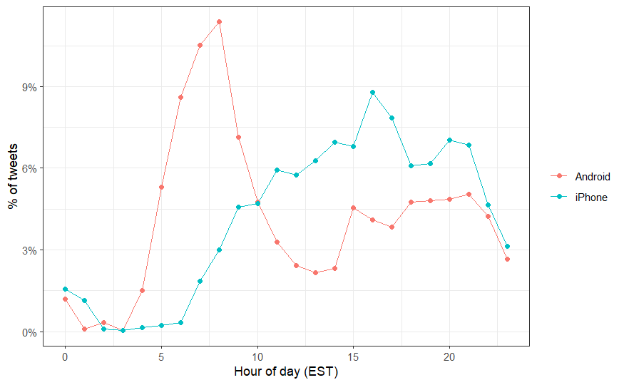

```r
campaign_tweets %>% ggplot(aes(hour, percent, color = source)) +
  geom_line() +
  geom_point() +
  scale_y_continuous(labels = percent_format()) +
  labs(x = "Hour of day (EST)",
       y = "% of tweets",
       color = "")
```

Pode-se verificar que entre 6 e 8 horas existe um pico acentuado de tweets vindos somente do Android, reforçando a tese que tratam-se de duas entidades diferentes.

## Analisando os textos

```r
library(tidytext)
```

```r
example <- data.frame(line = c(1, 2, 3, 4),
                    txt = c("Roses are red,", "Violets are blue,", "Sugar is sweet,", "And so are you."))
example
```

| line | txt |
| --- | --- |
| 1 | Roses are red, |
| 2 | Violets are blue, |
| 3 | Sugar is sweet, |
| 4 | And so are you. |

```r
example %>% unnest_tokens(word, txt)
```

| line | word |
| --- | --- |
| 1 | roses |
| 1 | are |
| 1 | red |
| 2 | violets |
| 2 | are |
| 2 | blue |
| 3 | sugar |
| 3 | is |
| 3 | sweet |
| 4 | and |

[output cut: 3 more lines]

Extraindo tweets - Voltando ao exemplo de Trump

```r
campaign_tweets <- trump_tweets %>% extract(source, "source", "Twitter for (.*)") %>%   filter(source %in% c("Android", "iPhone") &  created_at >= ymd("2015-06-17") & created_at < ymd("2016-11-08")) %>%  filter(!is_retweet) %>%
  arrange(created_at)
campaign_tweets
```

| source | id_str | text | created_at | retweet_count | in_reply_to_user_id_str | favorite_count | is_retweet |
| --- | --- | --- | --- | --- | --- | --- | --- |
| Android | 612063082186174464 | Why did @DanaPerino beg me for a tweet (endorsement) when her book was launched? | 2015-06-19 20:03:05 | 166 | NA | 348 | FALSE |
| Android | 612066176294866945 | I like Mexico and love the spirit of Mexican people, but we must protect our borders from people, from all over, pouring into the U.S. | 2015-06-19 20:15:22 | 1266 | NA | 2118 | FALSE |
| Android | 612076000529268736 | Mexico is killing the United States economically because their leaders and negotiators are FAR smarter than ours. But nobody beats Trump! | 2015-06-19 20:54:25 | 1033 | NA | 1770 | FALSE |
| Android | 612083064945180672 | Druggies, drug dealers, rapists and killers are coming across the southern border. When will the U.S. get smart and stop this travesty? | 2015-06-19 21:22:29 | 1578 | NA | 2181 | FALSE |
| Android | 612406758351478788 | My speech is right now on C-SPAN 1 | 2015-06-20 18:48:43 | 86 | NA | 312 | FALSE |
| Android | 612415976890593284 | Thank you @AnnCoulter for your nice words. The U.S. is becoming a dumping ground for the world. Pols don't get it. Make America Great Again! | 2015-06-20 19:25:21 | 299 | NA | 643 | FALSE |
| Android | 612424168055939072 | Who would you rather have negotiating for the U.S. against Putin, Iran, China, etc., Donald Trump or Hillary? Is there even a little doubt? | 2015-06-20 19:57:54 | 1270 | NA | 2128 | FALSE |
| Android | 612748954925670401 | .@KarlRove, who spent $430 million in the last cycle and didn't win one race, said I'm not a candidate until I file papers. Next week Karl! | 2015-06-21 17:28:29 | 165 | NA | 343 | FALSE |
| Android | 612759913127890944 | .@MarthaRaddatz was so unprofessional and biased when discussing me on This Week. @GStephanopoulos should not allow this conduct! | 2015-06-21 18:12:02 | 104 | NA | 258 | FALSE |
| Android | 612769697235386368 | The great Mike Wallace covered me in a much more professional manner than his son, Chris Wallace of @FoxNews. Mike was a total pro! | 2015-06-21 18:50:55 | 94 | NA | 297 | FALSE |

[output cut: 990 more lines]

Tokenizando um tweet aleatorio

```r
i <- 3008
campaign_tweets$text[i]
```

```
[1] "Great to be back in Iowa! #TBT with @JerryJrFalwell joining me in Davenport- this past winter. #MAGA https://t.co/A5IF0QHnic"
```

```r
i <- 3008
campaign_tweets[i,] %>% select(text) %>% unnest_tokens(word, text)
```

| word |
| --- |
| great |
| to |
| be |
| back |
| in |
| iowa |
| tbt |
| with |
| jerryjrfalwell |
| joining |

[output cut: 10 more lines]

Podemos ver que o “#TBT” não foi tokenizado, “@JerryJrFalwell” tornou-se “jerryjrfalwell”  
Para poder pegar corretamente vamos utilizar expressões regulares ao invés do argumento já implementado “word”

```r
i <- 3008
pattern <- "([^A-Za-z\\d#@']|'(?![A-Za-z\\d#@]))"
campaign_tweets[i,] %>% select(text) %>% unnest_tokens(word, text, token = "regex", pattern = pattern)
```

| word |
| --- |
| great |
| to |
| be |
| back |
| in |
| iowa |
| #tbt |
| with |
| @jerryjrfalwell |
| joining |

[output cut: 11 more lines]

Não é necessário pegar links

```r
i <- 3008
campaign_tweets[i,] %>% select(text) %>% str_replace_all("https://t.co/[A-Za-z\\d]+|&amp;", "")
```

```
[1] "Great to be back in Iowa! #TBT with @JerryJrFalwell joining me in Davenport- this past winter. #MAGA "
```

Substituindo para todos os tweets

```r
tweet_words2 <- campaign_tweets %>% mutate(text = str_replace_all(text, "https://t.co/[A-Za-z\\d]+|&amp;", ""))
```

```r
tweet_words2[3008,]
```

|  | source | id_str | text | created_at | retweet_count | in_reply_to_user_id_str | favorite_count | is_retweet |
| --- | --- | --- | --- | --- | --- | --- | --- | --- |
| 3008 | iPhone | 758771144140820481 | Great to be back in Iowa! #TBT with @JerryJrFalwell joining me in Davenport- this past winter. #MAGA | 2016-07-28 16:08:32 | 4355 | NA | 17114 | FALSE |

Agora vamos extrair as palavras de todos os tweets

```r
pattern <- "([^A-Za-z\\d#@']|'(?![A-Za-z\\d#@]))"
tweet_words2 %>% select(text) %>% unnest_tokens(word, text, token = "regex", pattern = pattern)
```

| word |
| --- |
| why |
| did |
| @danaperino |
| beg |
| me |
| for |
| a |
| tweet |
| endorsement |
| when |

[output cut: 990 more lines]

```r
count_word <- tweet_words2 %>% select(text) %>% unnest_tokens(word, text, token = "regex", pattern = pattern)

count_word %>% count(word) %>%  arrange(desc(n))
```

| word | n |
| --- | --- |
| the | 2335 |
| to | 1413 |
| and | 1246 |
| a | 1210 |
| in | 1189 |
| i | 1161 |
| you | 1000 |
| of | 983 |
| is | 944 |
| on | 880 |

[output cut: 990 more lines]

Removendo as palavras não informativas, os pacote tidytext já possui uma lista chamada stop_words

```r
count_word %>% filter(!word %in% stop_words$word) %>% count(word) %>% top_n(10, n) %>% arrange(desc(n))
```

| word | n |
| --- | --- |
| #trump2016 | 415 |
| hillary | 407 |
| people | 303 |
| #makeamericagreatagain | 296 |
| america | 254 |
| clinton | 239 |
| poll | 220 |
| crooked | 206 |
| trump | 199 |
| cruz | 162 |

## Separando as palavras por dispositivos

```r
#tweet_words
pattern <- "([^A-Za-z\\d#@']|'(?![A-Za-z\\d#@]))"

tweet_words2 %>% group_by(source) %>% select(source, text) %>%
  unnest_tokens(word, text, token = "regex", pattern = pattern) %>%
  filter(!word %in% stop_words$word) %>%
  count(word) %>%
  top_n(10, n) %>%
  arrange(desc(source),(desc(n)) )
```

| source | word | n |
| --- | --- | --- |
| iPhone | #trump2016 | 412 |
| iPhone | #makeamericagreatagain | 296 |
| iPhone | join | 157 |
| iPhone | america | 140 |
| iPhone | hillary | 117 |
| iPhone | people | 108 |
| iPhone | clinton | 103 |
| iPhone | poll | 103 |
| iPhone | tomorrow | 101 |
| iPhone | trump | 87 |

[output cut: 10 more lines]

```r
NA
```

Vamos analisar a proporção que uma palavra tem de aparecer em um iPhone ou Android

Tweet words: todas as palavras de todos os tweets de campanha tokenizadas

```r
tweet_words <- campaign_tweets %>%
  mutate(text = str_replace_all(text, "https://t.co/[A-Za-z\\d]+|&amp;", ""))  %>%
  unnest_tokens(word, text, token = "regex", pattern = pattern)
```

Palavras mais provaveis de aparecer no Android:

```r
android_iphone_or <- tweet_words %>%
  count(word, source) %>%
  spread(source, n, fill = 0) %>%
  mutate(or = (Android + 0.5) / (sum(Android) - Android + 0.5) /
           ( (iPhone + 0.5) / (sum(iPhone) - iPhone + 0.5)))
android_iphone_or %>% filter(Android+iPhone > 100) %>%  arrange(desc(or))
```

| word | Android | iPhone | or |
| --- | --- | --- | --- |
| m | 110 | 3 | 22.779845983 |
| u | 101 | 11 | 6.365112244 |
| @cnn | 104 | 18 | 4.072953227 |
| big | 171 | 32 | 3.809466178 |
| many | 117 | 26 | 3.197257359 |
| bad | 104 | 26 | 2.842591776 |
| but | 133 | 35 | 2.711919805 |
| said | 108 | 29 | 2.651246084 |
| so | 249 | 69 | 2.593350411 |
| that | 378 | 109 | 2.501689707 |

[output cut: 99 more lines]

```r
NA
NA
```

**Aqui existe uma passagem não trivial para odds_ratio:**

```r
or = (Android + 0.5) / (sum(Android) - Android + 0.5)
```

**Por que or = Android / sum(Android) - Android ?**

Exemplo para a palavra “big”  
Construindo df:

```r
big_df <- data.frame (c("yes", "no", "total"), c(171 ,sum(android_iphone_or$Android)- 171, sum(android_iphone_or$Android) ), c(32 , sum( android_iphone_or$iPhone)- 32, sum( android_iphone_or$iPhone) ))
names(big_df) <- c("big", "Android", "iPhone")
big_df
```

| big | Android | iPhone |
| --- | --- | --- |
| yes | 171 | 32 |
| no | 39832 | 28755 |
| total | 40003 | 28787 |

Calculando o odds ratio para Android:

$Android_{or} = \frac{yes}{total}:\frac{no}{total}$  
$no = total - yes$  
$Android_{or} = \frac{yes}{total} . \frac{total}{total - yes}$  
$Android_{or} = \frac{yes}{total - yes}$

Por fim, Odds ratio Android x iPhone:  
$OR = \frac{Android_{or}}{iPhone_{or}}$

**No código utilizado pelo curso esta passagem está sendo colocada de forma direta**

Palavras mais provaveis de aparecer no IPhone:

```r
android_iphone_or %>% filter(Android+iPhone > 100) %>%  arrange(or)
```

[output not shown]

## Analise de sentimentos

No pacote tidytext existe mapas para realizar análise de sentimentos, que trata-se se dar um valor numérico, binário ou qualquer outra escala para cada palavra.

O mapa default agrupa palavras em positivas e negativas

```r
head(sentiments)
```

[output not shown]

O mapa afinn agrupa palavras em números de -5 a 5

```r
#install.packages("textdata")
head(get_sentiments("afinn"))
```

[output not shown]

A biblioteca nrc agrupa palavras em 10 sentimentos

```r
head (get_sentiments("nrc")) #%>% count(sentiment)
```

[output not shown]

Vamos utilizar o mapa nrc

```r
nrc <- get_sentiments("nrc") %>% select(word, sentiment)
```

Utilizando inner join (tabela resultando de palavras que estão nas duas listas)

```r
tweet_sentiments <- inner_join(tweet_words,nrc)
tweet_sentiments %>% group_by(source) %>% count(sentiment, word) %>% top_n(10,n) %>% arrange(desc(source), desc(n))
```

[output not shown]

```r
sentiment_counts <- tweet_words %>%
  left_join(nrc, by = "word") %>%
  count(source, sentiment) #%>%
  #spread(source, n) %>%
  #mutate(sentiment = replace_na(sentiment, replace = "none"))
sentiment_counts
```

[output not shown]

Agrupando Android e IPhone em colunas e n nas linhas, usa-se spread()

```r
sentiment_counts <- tweet_words %>%
  left_join(nrc, by = "word") %>%
  count(source, sentiment) %>%
  spread(source, n) %>%
  mutate(sentiment = replace_na(sentiment, replace = "none"))
sentiment_counts
```

| sentiment | Android | iPhone |
| --- | --- | --- |
| anger | 964 | 526 |
| anticipation | 1014 | 744 |
| disgust | 642 | 314 |
| fear | 834 | 498 |
| joy | 772 | 569 |
| negative | 1710 | 946 |
| positive | 2025 | 1583 |
| sadness | 933 | 522 |
| surprise | 601 | 387 |
| trust | 1413 | 1073 |

[output cut: 1 more lines]

```r
tweet_words %>% group_by(source) %>% summarize(n = n())
```

| source | n |
| --- | --- |
| Android | 40003 |
| iPhone | 28787 |

Calculando ODDs ratio:  
1 - Proporcao de cada sentimento para Android e iPhone  
2 - Divide-se ambas as proporção

Ex. Para o sentimento disgust:  
1.4% / 1%

```r
sentiment_counts %>%
  mutate(Android = Android / (sum(Android) - Android) ,
         iPhone = iPhone / (sum(iPhone) - iPhone),
         or = Android/iPhone) %>%
  arrange(desc(or))
```

| sentiment | Android | iPhone | or |
| --- | --- | --- | --- |
| disgust | 0.01406661 | 0.009678811 | 1.4533405 |
| anger | 0.02127190 | 0.016320199 | 1.3034094 |
| negative | 0.03836489 | 0.029739076 | 1.2900499 |
| sadness | 0.02057377 | 0.016194081 | 1.2704501 |
| fear | 0.01835064 | 0.015438031 | 1.1886647 |
| surprise | 0.01315645 | 0.011955884 | 1.1004167 |
| anticipation | 0.02239993 | 0.023241285 | 0.9637991 |
| joy | 0.01696330 | 0.017677945 | 0.9595745 |
| trust | 0.03149168 | 0.033866742 | 0.9298702 |
| none | 3.24294096 | 3.573582798 | 0.9074761 |

[output cut: 1 more lines]

Os sentimentos que possuem um maior OR são disgust, anger e negative. Será que possuem relevância significativa

Hipótese nula: Qual a probabilidade de se obter essa diferença de odds_ratio se os sentimentos fossem distribuidos de forma aleatória

```r
library(broom)
log_or <- sentiment_counts %>%
  mutate( log_or = log( (Android / (sum(Android) - Android)) / (iPhone / (sum(iPhone) - iPhone))),
          se = sqrt( 1/Android + 1/(sum(Android) - Android) + 1/iPhone + 1/(sum(iPhone) - iPhone)),
          conf.low = log_or - qnorm(0.975)*se,
          conf.high = log_or + qnorm(0.975)*se) %>%
  arrange(desc(log_or))

log_or
```

| sentiment | Android | iPhone | log_or | se | conf.low | conf.high |
| --- | --- | --- | --- | --- | --- | --- |
| disgust | 642 | 314 | 0.37386467 | 0.06924652 | 0.23814399 | 0.509585359 |
| anger | 964 | 526 | 0.26498347 | 0.05469532 | 0.15778261 | 0.372184336 |
| negative | 1710 | 946 | 0.25468093 | 0.04117949 | 0.17397062 | 0.335391236 |
| sadness | 933 | 522 | 0.23937128 | 0.05514159 | 0.13129576 | 0.347446806 |
| fear | 834 | 498 | 0.17283058 | 0.05709708 | 0.06092237 | 0.284738798 |
| surprise | 601 | 387 | 0.09568896 | 0.06557940 | -0.03284430 | 0.224222219 |
| anticipation | 1014 | 744 | -0.03687240 | 0.04882221 | -0.13256217 | 0.058817375 |
| joy | 772 | 569 | -0.04126532 | 0.05573013 | -0.15049437 | 0.067963731 |
| trust | 1413 | 1073 | -0.07271023 | 0.04115252 | -0.15336770 | 0.007947233 |
| none | 35374 | 25594 | -0.09708806 | 0.01728128 | -0.13095874 | -0.063217369 |

[output cut: 1 more lines]

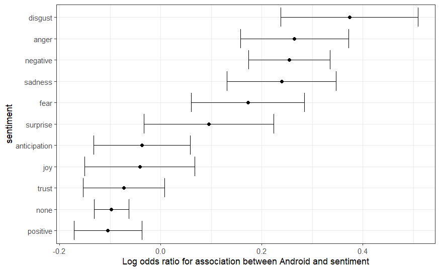

```r
log_or %>%
  mutate(sentiment = reorder(sentiment, log_or),) %>%
  ggplot(aes(x = sentiment, ymin = conf.low, ymax = conf.high)) +
  geom_errorbar() +
  geom_point(aes(sentiment, log_or)) +
  ylab("Log odds ratio for association between Android and sentiment") +
  coord_flip()
```